# Assignment 3 - Quant

Alex Cox

9/21/2020

## Assignment 3 Overview

For this assignment, I will examine the relationships between my 5 variables from the 2018 ACS survey in Virginia. As a reminder, those variables are:

1. Military Service - MIL (categorical)
2. Means of Transportation to Work - JWTR (categorical)
3. Income - PINCP (continuous)
4. Age - AGEP (continuous)
5. Travel time to work - JWMNP (continuous)

On Sara’s advice from last week, I simplified my dataset by filtering out individuals whose military service label was “N/A (Less than 17 years old)” or “Never served in the military.” Eliminating non-military personnel from the analysis has reduced the number of observations in my dataset from 38,815 to 5,045.

By my calculation, there are 10 relationships to examine between my variables (side note: my two categorical variables both have three or more levels). 1 relationship is between two categorical variables, 3 relationships are between two continuous variables, and 6 relationships are between one categorical variable and one continuous variable:

1. Military Service - Means of Transportation to Work (Categorical - Categorical)
2. Income - Age (Continuous - Continuous)
3. Income - Travel time to work (Continuous - Continuous)
4. Age - Travel time to work (Continuous - Continuous)
5. Military Service - Income (Categorical - Continuous)
6. Military Service - Age (Categorical - Continuous)
7. Military Service - Travel time to work (Categorical - Continuous)
8. Means of Transportation to Work - Income (Categorical - Continuous)
9. Means of Transportation to Work - Age (Categorical - Continuous)
10. Means of Transportation to Work - Travel time to work (Categorical - Continuous)

I should also note that Julia showed me how to add a feature to toggle code chunk visibility in my HTML document, which I’ve used for the first time on this assignment. Thanks, Julia!

```r
library(tidyverse)
library(ggplot2)
```

```r
military_data <- read_csv("militarycommute.csv")
```

## Comparisons Part I: Relationship between two categorical variables

1. Military Service - Means of Transportation to Work (Categorical - Categorical)

```r
options(scipen=999)
chi_sqCAR <- chisq.test(military_data$MIL_label, military_data$JWTR_label ==
                       "Car, truck, or van")
chi_sqCAR
```

```
##
##  Pearson's Chi-squared test
##
## data:  military_data$MIL_label and military_data$JWTR_label == "Car, truck, or van"
## X-squared = 110.02, df = 2, p-value < 0.00000000000000022
```

```r
chi_sqCAR$observed
```

```
##
## military_data$MIL_label                                       FALSE TRUE
##   Now on active duty                                            210  863
##   On active duty in the past, but not now                       305 3268
##   Only on active duty for training in Reserves/National Guard    29  370
```

```r
chi_sqCAR$expected
```

```
##
## military_data$MIL_label                                           FALSE
##   Now on active duty                                          115.70109
##   On active duty in the past, but not now                     385.27493
##   Only on active duty for training in Reserves/National Guard  43.02398
##
## military_data$MIL_label                                            TRUE
##   Now on active duty                                           957.2989
##   On active duty in the past, but not now                     3187.7251
##   Only on active duty for training in Reserves/National Guard  355.9760
```

```r
options(scipen=999)
chi_sqWALK <- chisq.test(military_data$MIL_label, military_data$JWTR_label ==
                       "Walked")
chi_sqWALK
```

```
##
##  Pearson's Chi-squared test
##
## data:  military_data$MIL_label and military_data$JWTR_label == "Walked"
## X-squared = 252.14, df = 2, p-value < 0.00000000000000022
```

```r
chi_sqWALK$observed
```

```
##
## military_data$MIL_label                                       FALSE TRUE
##   Now on active duty                                            940  133
##   On active duty in the past, but not now                      3513   60
##   Only on active duty for training in Reserves/National Guard   391    8
```

```r
chi_sqWALK$expected
```

```
##
## military_data$MIL_label                                           FALSE
##   Now on active duty                                          1030.2501
##   On active duty in the past, but not now                     3430.6466
##   Only on active duty for training in Reserves/National Guard  383.1033
##
## military_data$MIL_label                                            TRUE
##   Now on active duty                                           42.74985
##   On active duty in the past, but not now                     142.35342
##   Only on active duty for training in Reserves/National Guard  15.89673
```

```r
options(scipen=999)
chi_sqOTHER <- chisq.test(military_data$MIL_label, military_data$JWTR_label ==
                       "Other method")
chi_sqOTHER
```

```
##
##  Pearson's Chi-squared test
##
## data:  military_data$MIL_label and military_data$JWTR_label == "Other method"
## X-squared = 2.7814, df = 2, p-value = 0.2489
```

```r
chi_sqOTHER$observed
```

```
##
## military_data$MIL_label                                       FALSE TRUE
##   Now on active duty                                           1060   13
##   On active duty in the past, but not now                      3534   39
##   Only on active duty for training in Reserves/National Guard   398    1
```

```r
chi_sqWALK$expected
```

```
##
## military_data$MIL_label                                           FALSE
##   Now on active duty                                          1030.2501
##   On active duty in the past, but not now                     3430.6466
##   Only on active duty for training in Reserves/National Guard  383.1033
##
## military_data$MIL_label                                            TRUE
##   Now on active duty                                           42.74985
##   On active duty in the past, but not now                     142.35342
##   Only on active duty for training in Reserves/National Guard  15.89673
```

```r
chi_sqBIKE <- chisq.test(military_data$MIL_label, military_data$JWTR_label ==
                       "Bicycle")
chi_sqBIKE
```

```
##
##  Pearson's Chi-squared test
##
## data:  military_data$MIL_label and military_data$JWTR_label == "Bicycle"
## X-squared = 1.7588, df = 2, p-value = 0.415
```

```r
chi_sqBIKE$observed
```

```
##
## military_data$MIL_label                                       FALSE TRUE
##   Now on active duty                                           1068    5
##   On active duty in the past, but not now                      3565    8
##   Only on active duty for training in Reserves/National Guard   398    1
```

```r
chi_sqWALK$expected
```

```
##
## military_data$MIL_label                                           FALSE
##   Now on active duty                                          1030.2501
##   On active duty in the past, but not now                     3430.6466
##   Only on active duty for training in Reserves/National Guard  383.1033
##
## military_data$MIL_label                                            TRUE
##   Now on active duty                                           42.74985
##   On active duty in the past, but not now                     142.35342
##   Only on active duty for training in Reserves/National Guard  15.89673
```

```r
chi_sqBUS <- chisq.test(military_data$MIL_label, military_data$JWTR_label ==
                       "Bus or trolley bus")
chi_sqBUS
```

```
##
##  Pearson's Chi-squared test
##
## data:  military_data$MIL_label and military_data$JWTR_label == "Bus or trolley bus"
## X-squared = 1.1644, df = 2, p-value = 0.5587
```

```r
chi_sqBUS$observed
```

```
##
## military_data$MIL_label                                       FALSE TRUE
##   Now on active duty                                           1052   21
##   On active duty in the past, but not now                      3500   73
##   Only on active duty for training in Reserves/National Guard   394    5
```

```r
chi_sqWALK$expected
```

```
##
## military_data$MIL_label                                           FALSE
##   Now on active duty                                          1030.2501
##   On active duty in the past, but not now                     3430.6466
##   Only on active duty for training in Reserves/National Guard  383.1033
##
## military_data$MIL_label                                            TRUE
##   Now on active duty                                           42.74985
##   On active duty in the past, but not now                     142.35342
##   Only on active duty for training in Reserves/National Guard  15.89673
```

```r
chi_sqSUBWAY <- chisq.test(military_data$MIL_label, military_data$JWTR_label ==
                       "Subway or elevated")
chi_sqSUBWAY
```

```
##
##  Pearson's Chi-squared test
##
## data:  military_data$MIL_label and military_data$JWTR_label == "Subway or elevated"
## X-squared = 0.64282, df = 2, p-value = 0.7251
```

```r
chi_sqSUBWAY$observed
```

```
##
## military_data$MIL_label                                       FALSE TRUE
##   Now on active duty                                           1048   25
##   On active duty in the past, but not now                      3503   70
##   Only on active duty for training in Reserves/National Guard   390    9
```

```r
chi_sqWALK$expected
```

```
##
## military_data$MIL_label                                           FALSE
##   Now on active duty                                          1030.2501
##   On active duty in the past, but not now                     3430.6466
##   Only on active duty for training in Reserves/National Guard  383.1033
##
## military_data$MIL_label                                            TRUE
##   Now on active duty                                           42.74985
##   On active duty in the past, but not now                     142.35342
##   Only on active duty for training in Reserves/National Guard  15.89673
```

```r
chi_sqMOTORCYCLE <- chisq.test(military_data$MIL_label, military_data$JWTR_label ==
                       "Motorcycle")
chi_sqMOTORCYCLE
```

```
##
##  Pearson's Chi-squared test
##
## data:  military_data$MIL_label and military_data$JWTR_label == "Motorcycle"
## X-squared = 0.53041, df = 2, p-value = 0.767
```

```r
chi_sqMOTORCYCLE$observed
```

```
##
## military_data$MIL_label                                       FALSE TRUE
##   Now on active duty                                           1068    5
##   On active duty in the past, but not now                      3561   12
##   Only on active duty for training in Reserves/National Guard   398    1
```

```r
chi_sqWALK$expected
```

```
##
## military_data$MIL_label                                           FALSE
##   Now on active duty                                          1030.2501
##   On active duty in the past, but not now                     3430.6466
##   Only on active duty for training in Reserves/National Guard  383.1033
##
## military_data$MIL_label                                            TRUE
##   Now on active duty                                           42.74985
##   On active duty in the past, but not now                     142.35342
##   Only on active duty for training in Reserves/National Guard  15.89673
```

```r
chi_sqTAXI <- chisq.test(military_data$MIL_label, military_data$JWTR_label ==
                       "Taxicab")
chi_sqTAXI
```

```
##
##  Pearson's Chi-squared test
##
## data:  military_data$MIL_label and military_data$JWTR_label == "Taxicab"
## X-squared = 1.3521, df = 2, p-value = 0.5086
```

```r
chi_sqTAXI$observed
```

```
##
## military_data$MIL_label                                       FALSE TRUE
##   Now on active duty                                           1070    3
##   On active duty in the past, but not now                      3567    6
##   Only on active duty for training in Reserves/National Guard   399    0
```

```r
chi_sqWALK$expected
```

```
##
## military_data$MIL_label                                           FALSE
##   Now on active duty                                          1030.2501
##   On active duty in the past, but not now                     3430.6466
##   Only on active duty for training in Reserves/National Guard  383.1033
##
## military_data$MIL_label                                            TRUE
##   Now on active duty                                           42.74985
##   On active duty in the past, but not now                     142.35342
##   Only on active duty for training in Reserves/National Guard  15.89673
```

```r
chi_sqRAIL <- chisq.test(military_data$MIL_label, military_data$JWTR_label ==
                       "Railroad")
chi_sqRAIL
```

```
##
##  Pearson's Chi-squared test
##
## data:  military_data$MIL_label and military_data$JWTR_label == "Railroad"
## X-squared = 3.4493, df = 2, p-value = 0.1782
```

```r
chi_sqRAIL$observed
```

```
##
## military_data$MIL_label                                       FALSE TRUE
##   Now on active duty                                           1069    4
##   On active duty in the past, but not now                      3539   34
##   Only on active duty for training in Reserves/National Guard   396    3
```

```r
chi_sqWALK$expected
```

```
##
## military_data$MIL_label                                           FALSE
##   Now on active duty                                          1030.2501
##   On active duty in the past, but not now                     3430.6466
##   Only on active duty for training in Reserves/National Guard  383.1033
##
## military_data$MIL_label                                            TRUE
##   Now on active duty                                           42.74985
##   On active duty in the past, but not now                     142.35342
##   Only on active duty for training in Reserves/National Guard  15.89673
```

```r
chi_sqFERRY <- chisq.test(military_data$MIL_label, military_data$JWTR_label ==
                       "Ferryboat")
chi_sqFERRY
```

```
##
##  Pearson's Chi-squared test
##
## data:  military_data$MIL_label and military_data$JWTR_label == "Ferryboat"
## X-squared = 3.0992, df = 2, p-value = 0.2123
```

```r
chi_sqFERRY$observed
```

```
##
## military_data$MIL_label                                       FALSE TRUE
##   Now on active duty                                           1073    0
##   On active duty in the past, but not now                      3571    2
##   Only on active duty for training in Reserves/National Guard   398    1
```

```r
chi_sqWALK$expected
```

```
##
## military_data$MIL_label                                           FALSE
##   Now on active duty                                          1030.2501
##   On active duty in the past, but not now                     3430.6466
##   Only on active duty for training in Reserves/National Guard  383.1033
##
## military_data$MIL_label                                            TRUE
##   Now on active duty                                           42.74985
##   On active duty in the past, but not now                     142.35342
##   Only on active duty for training in Reserves/National Guard  15.89673
```

```r
chi_sqTROLLEY <- chisq.test(military_data$MIL_label, military_data$JWTR_label ==
                       "Streetcar or trolley car (carro publico in Puerto Rico)")
chi_sqTROLLEY
```

```
##
##  Pearson's Chi-squared test
##
## data:  military_data$MIL_label and military_data$JWTR_label == "Streetcar or trolley car (carro publico in Puerto Rico)"
## X-squared = 1.0573, df = 2, p-value = 0.5894
```

```r
chi_sqTROLLEY$observed
```

```
##
## military_data$MIL_label                                       FALSE TRUE
##   Now on active duty                                           1072    1
##   On active duty in the past, but not now                      3572    1
##   Only on active duty for training in Reserves/National Guard   399    0
```

```r
chi_sqWALK$expected
```

```
##
## military_data$MIL_label                                           FALSE
##   Now on active duty                                          1030.2501
##   On active duty in the past, but not now                     3430.6466
##   Only on active duty for training in Reserves/National Guard  383.1033
##
## military_data$MIL_label                                            TRUE
##   Now on active duty                                           42.74985
##   On active duty in the past, but not now                     142.35342
##   Only on active duty for training in Reserves/National Guard  15.89673
```

## Comparisons Part II: Relationship between two continuous variables

2. Income - Age (Continuous - Continuous)

I would say there’s a clear correlation between age and income among current and former service members, which isn’t a big surprise. The number of high-income outliers does make the chart a bit difficult to read. I’m also curious why there is such a clear line of datapoints at the $500,000 mark.

```r
correlation <- cor.test(military_data$AGEP, military_data$PINCP)

correlation
```

```
##
##  Pearson's product-moment correlation
##
## data:  military_data$AGEP and military_data$PINCP
## t = 25.329, df = 5043, p-value < 0.00000000000000022
## alternative hypothesis: true correlation is not equal to 0
## 95 percent confidence interval:
##  0.3112334 0.3601996
## sample estimates:
##       cor
## 0.3359435
```

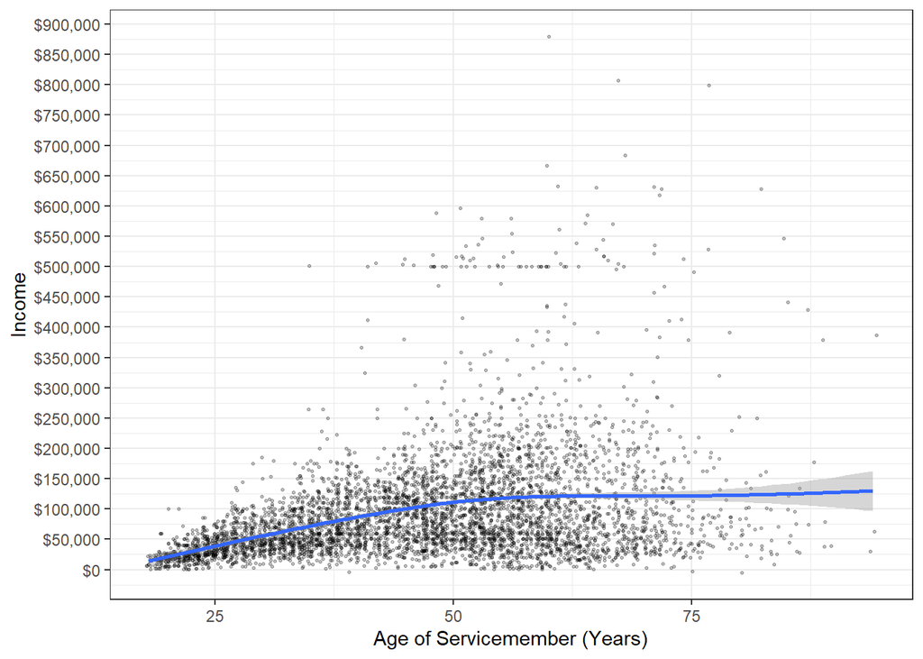

```r
ggplot(military_data, aes(x = AGEP, y = PINCP)) +
  geom_point(size = 0.5, alpha = 0.25, position = "jitter") +
  geom_smooth() +
  theme_bw() +
  scale_x_continuous(name = "Age of Servicemember (Years)") +
  scale_y_continuous(name = "Income",
                     breaks = seq(0, 1000000, by = 50000),
                     labels = scales::dollar_format())
```

3. Income - Travel time to work (Continuous - Continuous)

There seems to be an interesting correlation of commute times tending to increase along with income. However, I think the outliers at the high ends of both variables are making it difficult to see the trend for the majority of people.

```r
correlation <- cor.test(military_data$JWMNP, military_data$PINCP)

correlation
```

```
##
##  Pearson's product-moment correlation
##
## data:  military_data$JWMNP and military_data$PINCP
## t = 12.52, df = 5043, p-value < 0.00000000000000022
## alternative hypothesis: true correlation is not equal to 0
## 95 percent confidence interval:
##  0.1467303 0.2002585
## sample estimates:
##       cor
## 0.1736226
```

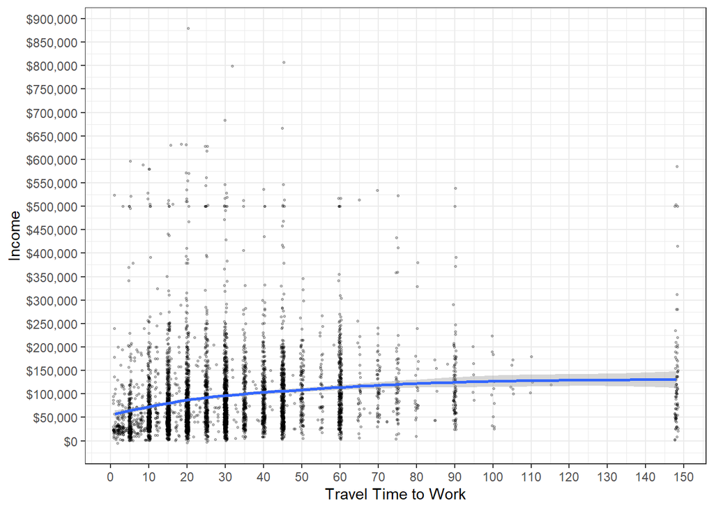

```r
ggplot(military_data, aes(x = JWMNP, y = PINCP)) +
  geom_point(size = 0.5, alpha = 0.25, position = "jitter") +
  geom_smooth() +
  theme_bw() +
  scale_x_continuous(name = "Travel Time to Work",
                     breaks = seq(0, 150, by = 10)) +
  scale_y_continuous(name = "Income",
                     breaks = seq(0, 1000000, by = 50000),
                     labels = scales::dollar_format())
```

4. Age - Travel time to work (Continuous - Continuous)

There seems to be a correlation between age and travel time to work, as younger and older personnel have generally shorter commute times than those in middle age according to the trend line (also affected by several outliers with 150-minute commutes around this age).

```r
correlation <- cor.test(military_data$AGEP, military_data$JWMNP)

correlation
```

```
##
##  Pearson's product-moment correlation
##
## data:  military_data$AGEP and military_data$JWMNP
## t = 7.9737, df = 5043, p-value = 0.000000000000001891
## alternative hypothesis: true correlation is not equal to 0
## 95 percent confidence interval:
##  0.08424562 0.13874975
## sample estimates:
##       cor
## 0.1115816
```

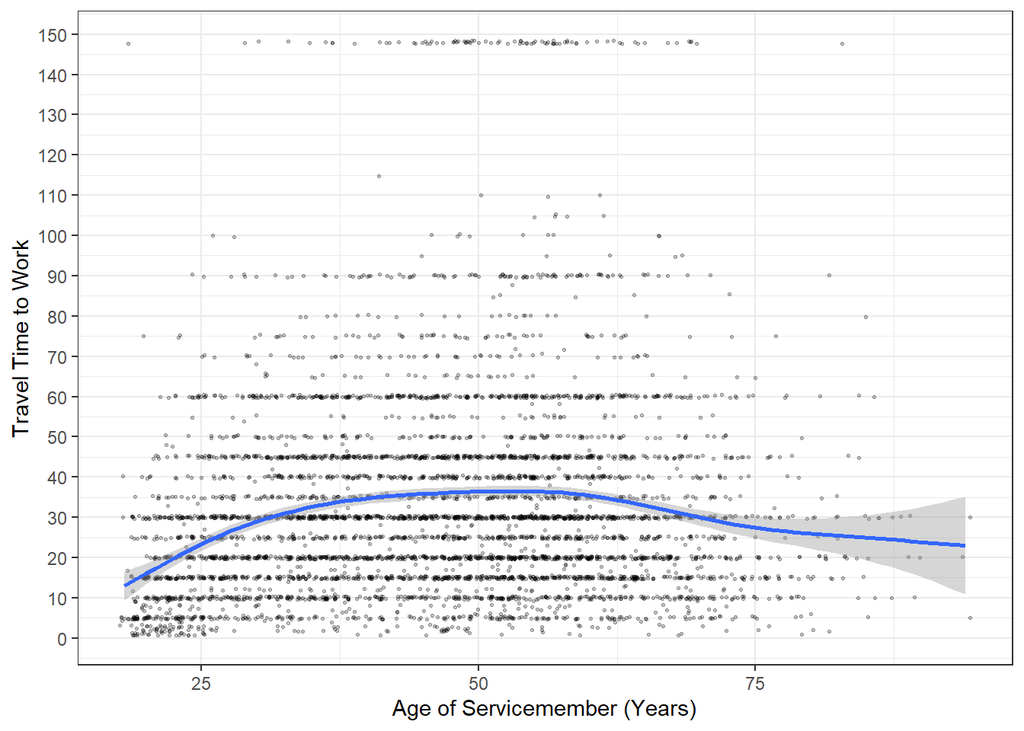

```r
ggplot(military_data, aes(x = AGEP, y = JWMNP)) +
  geom_point(size = 0.5, alpha = 0.25, position = "jitter") +
  geom_smooth() +
  theme_bw() +
  scale_x_continuous(name = "Age of Servicemember (Years)") +
  scale_y_continuous(name = "Travel Time to Work",
                     breaks = seq(0, 150, by = 10))
```

## Comparisons Part III: Relationship between a continuous variable and a categorical variable (three or more levels)

5. Military Service - Income (Categorical - Continuous)

There appears to be a strong correlation between income and military service status, with those who were on active duty in the past but not now tending to have significantly higher income.

```r
anova <- aov(PINCP ~ MIL_label, data = military_data)
options(scipen=999)
summary(anova)
```

```
##               Df         Sum Sq      Mean Sq F value              Pr(>F)
## MIL_label      2  1480959827188 740479913594   103.1 <0.0000000000000002 ***
## Residuals   5042 36226638177873   7184973855
## ---
## Signif. codes:  0 '***' 0.001 '**' 0.01 '*' 0.05 '.' 0.1 ' ' 1
```

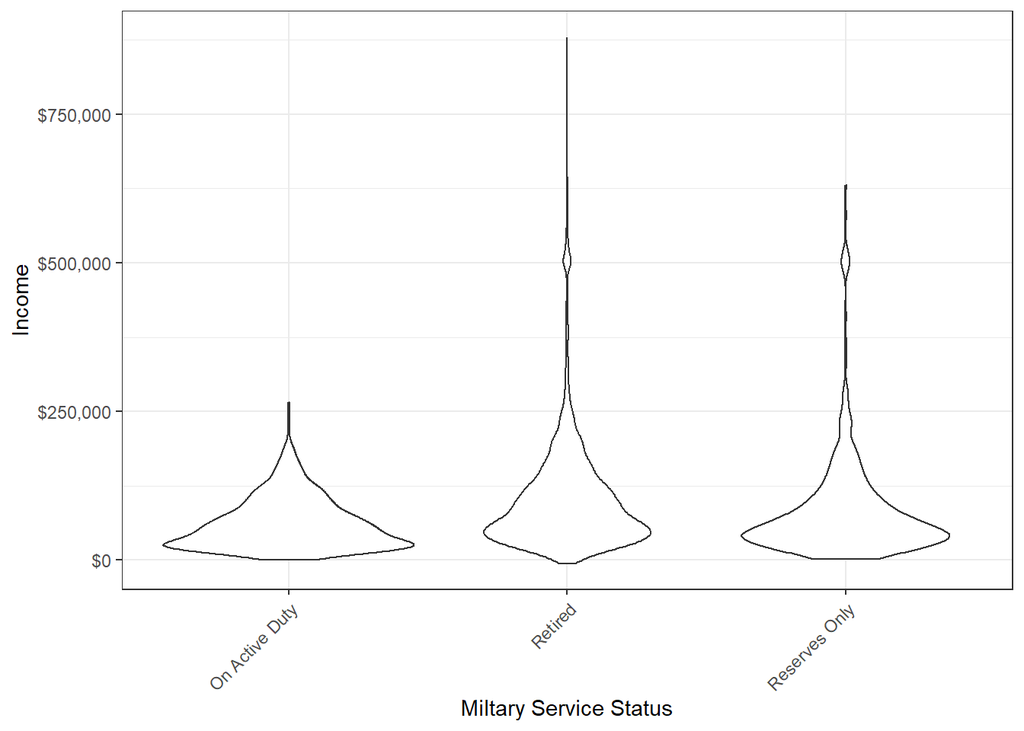

```r
ggplot(military_data, aes(x = MIL_label, y = PINCP)) +
  geom_violin() +
  theme_bw() +
  theme(axis.text.x = element_text(angle = 45, hjust = 1)) +
  scale_x_discrete(name = "Miltary Service Status",
                     labels = c("On Active Duty",
                                "Retired",
                                "Reserves Only")) +
  scale_y_continuous(name = "Income",
                     labels = scales::dollar_format())
```

6. Military Service - Age (Categorical - Continuous)

There is also a strong correlation between military service status and age, as those on active duty tend to be younger than those retired (not exactly a surprising finding).

```r
anova <- aov(AGEP ~ MIL_label, data = military_data)
options(scipen=999)
summary(anova)
```

```
##               Df Sum Sq Mean Sq F value              Pr(>F)
## MIL_label      2 305970  152985   941.9 <0.0000000000000002 ***
## Residuals   5042 818948     162
## ---
## Signif. codes:  0 '***' 0.001 '**' 0.01 '*' 0.05 '.' 0.1 ' ' 1
```

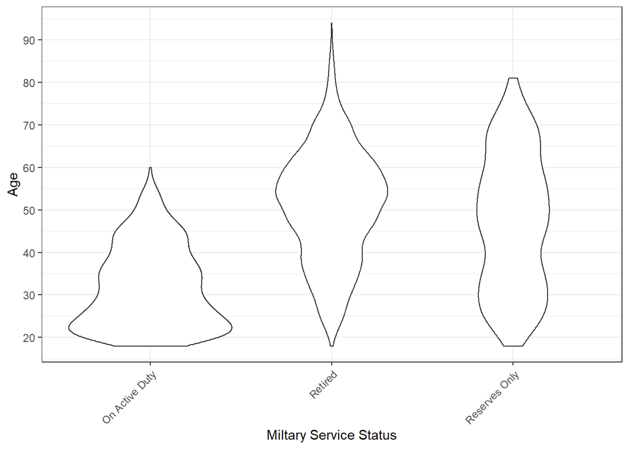

```r
ggplot(military_data, aes(x = MIL_label, y = AGEP)) +
  geom_violin() +
  theme_bw() +
  theme(axis.text.x = element_text(angle = 45, hjust = 1)) +
  scale_x_discrete(name = "Miltary Service Status",
                     labels = c("On Active Duty",
                                "Retired",
                                "Reserves Only")) +
  scale_y_continuous(name = "Age",
                     breaks = seq(0, 100, by = 10))
```

7. Military Service - Travel time to work (Categorical - Continuous)

The very small p-value indicates a strong correlation between military service and travel time to work, although in looking at the violin plot the numbers seem to be somewhat evenly distributed across different statuses.

```r
anova <- aov(JWMNP ~ MIL_label, data = military_data)
options(scipen=999)
summary(anova)
```

```
##               Df  Sum Sq Mean Sq F value              Pr(>F)
## MIL_label      2   56915   28458   47.09 <0.0000000000000002 ***
## Residuals   5042 3046673     604
## ---
## Signif. codes:  0 '***' 0.001 '**' 0.01 '*' 0.05 '.' 0.1 ' ' 1
```

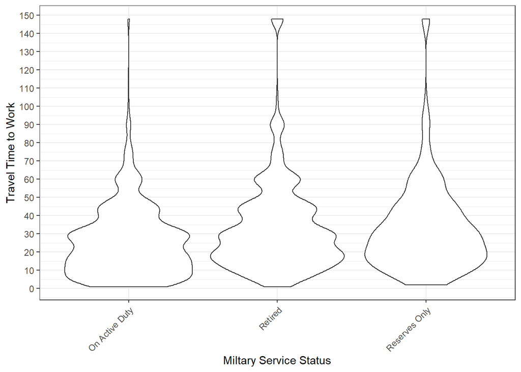

```r
ggplot(military_data, aes(x = MIL_label, y = JWMNP)) +
  geom_violin() +
  theme_bw() +
  theme(axis.text.x = element_text(angle = 45, hjust = 1)) +
  scale_x_discrete(name = "Miltary Service Status",
                     labels = c("On Active Duty",
                                "Retired",
                                "Reserves Only")) +
  scale_y_continuous(name = "Travel Time to Work",
                     breaks = seq(0, 150, by = 10))
```

8. Means of Transportation to Work - Income (Categorical - Continuous)

A very strong correlation between means of transportation to work and income, which is not surprising. However, I’m intrigued by the spread amongst modes such as walking. I switched to boxplots for these analyses because I think the 11 variables for “Means of Transportation to Work” makes violin plots too small and skinny to read.

```r
anova <- aov(PINCP ~ JWTR_label, data = military_data)
options(scipen=999)
summary(anova)
```

```
##               Df         Sum Sq     Mean Sq F value              Pr(>F)
## JWTR_label    10   993392164134 99339216413   13.62 <0.0000000000000002 ***
## Residuals   5034 36714205840928  7293247088
## ---
## Signif. codes:  0 '***' 0.001 '**' 0.01 '*' 0.05 '.' 0.1 ' ' 1
```

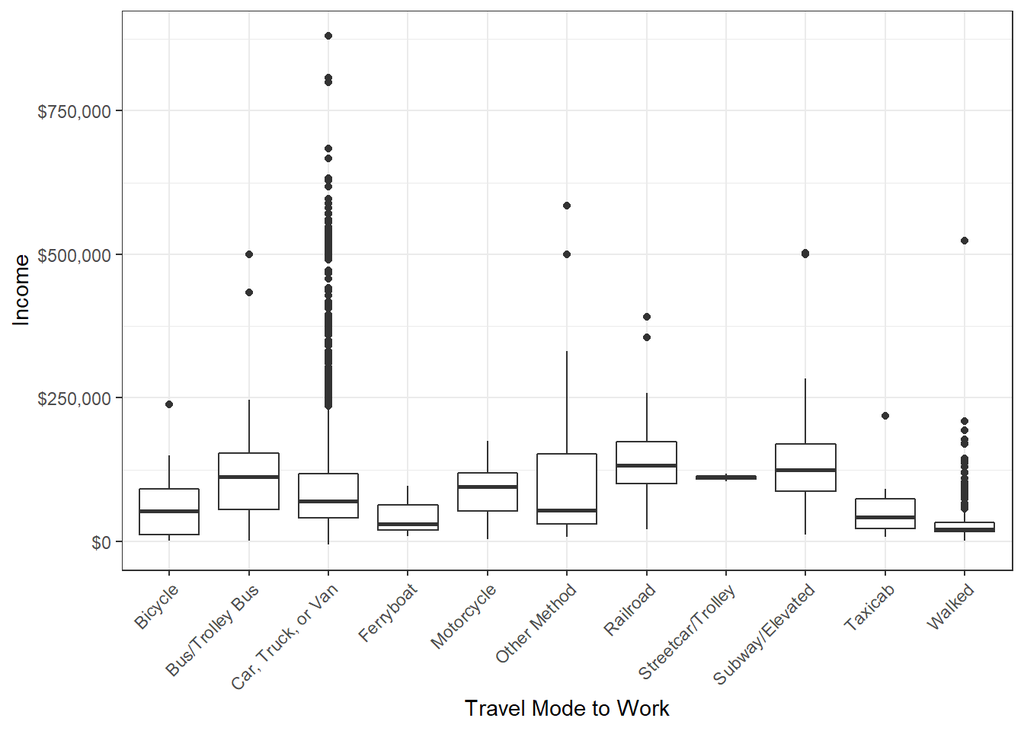

```r
ggplot(military_data, aes(x = JWTR_label, y = PINCP)) +
  geom_boxplot() +
  theme_bw() +
  theme(axis.text.x = element_text(angle = 45, hjust = 1)) +
  scale_x_discrete(name = "Travel Mode to Work",
                     labels = c("Bicycle",
                                "Bus/Trolley Bus",
                                "Car, Truck, or Van",
                                "Ferryboat",
                                "Motorcycle",
                                "Other Method",
                                "Railroad",
                                "Streetcar/Trolley",
                                "Subway/Elevated",
                                "Taxicab",
                                "Walked")) +
  scale_y_continuous(name = "Income",
                     labels = scales::dollar_format())
```

9. Means of Transportation to Work - Age (Categorical - Continuous)

The difference between active transportation modes was interesting to me here - the median age for walking to work is much lower than biking, which falls between 40-55 along with most other modes. However, this may be skewed because so many active duty members walk to work, and we saw from the age-military service comparison that they skewed younger.

```r
anova <- aov(AGEP ~ JWTR_label, data = military_data)
options(scipen=999)
summary(anova)
```

```
##               Df  Sum Sq Mean Sq F value              Pr(>F)
## JWTR_label    10   51576    5158   24.19 <0.0000000000000002 ***
## Residuals   5034 1073342     213
## ---
## Signif. codes:  0 '***' 0.001 '**' 0.01 '*' 0.05 '.' 0.1 ' ' 1
```

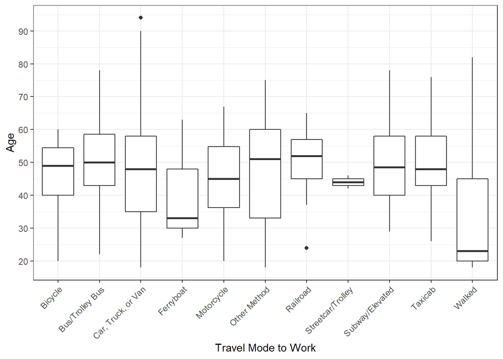

```r
ggplot(military_data, aes(x = JWTR_label, y = AGEP)) +
  geom_boxplot() +
  theme_bw() +
  theme(axis.text.x = element_text(angle = 45, hjust = 1)) +
  scale_x_discrete(name = "Travel Mode to Work",
                     labels = c("Bicycle",
                                "Bus/Trolley Bus",
                                "Car, Truck, or Van",
                                "Ferryboat",
                                "Motorcycle",
                                "Other Method",
                                "Railroad",
                                "Streetcar/Trolley",
                                "Subway/Elevated",
                                "Taxicab",
                                "Walked")) +
  scale_y_continuous(name = "Age",
                     breaks = seq(0, 100, by = 10))
```

10. Means of Transportation to Work - Travel time to work (Categorical - Continuous)

Aha! Here’s a comparison that is always fascinating to look into. Clearly there is a strong correlation between commute mode and commute time. It seems like car/truck/van/motorcycle users consistently report shorter commute times, but I was pleased to see that walking still provided a very short commute for those who live close to work. The ferryboat and streetcar commute times seem unusually high, but those were reported by a very small number of commuters overall.

```r
anova <- aov(JWMNP ~ JWTR_label, data = military_data)
options(scipen=999)
summary(anova)
```

```
##               Df  Sum Sq Mean Sq F value              Pr(>F)
## JWTR_label    10  329213   32921   59.73 <0.0000000000000002 ***
## Residuals   5034 2774375     551
## ---
## Signif. codes:  0 '***' 0.001 '**' 0.01 '*' 0.05 '.' 0.1 ' ' 1
```

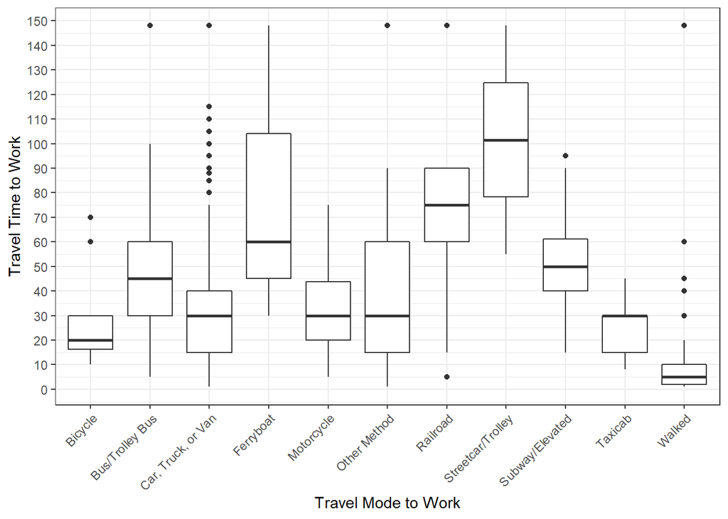

```r
ggplot(military_data, aes(x = JWTR_label, y = JWMNP)) +
  geom_boxplot() +
  theme_bw() +
  theme(axis.text.x = element_text(angle = 45, hjust = 1)) +
  scale_x_discrete(name = "Travel Mode to Work",
                     labels = c("Bicycle",
                                "Bus/Trolley Bus",
                                "Car, Truck, or Van",
                                "Ferryboat",
                                "Motorcycle",
                                "Other Method",
                                "Railroad",
                                "Streetcar/Trolley",
                                "Subway/Elevated",
                                "Taxicab",
                                "Walked")) +
  scale_y_continuous(name = "Travel Time to Work",
                     breaks = seq(0, 150, by = 10))
```